# Genetic algorithm using the evola package

Giovanny Covarrubias-Pazaran

2026-09-10

The evola package is nice wrapper of the AlphaSimR package that enables the use of the evolutionary algorithm (EA) to solve complex questions in a simple manner.

The vignettes aim to provide several examples in how to use the evola package under different optimization scenarios. We will spend the rest of the space providing examples for:

1. Optimizing the selection of one feature with a constraint in another feature
2. Obtaining an optimal subsample of a population to maximize a feature while constraining the relationship between individuals in the population 2a) best parents for the next generation in breeding 2b) best crosses of the next generation in breeding
3. Optimizing a subsample of size N to be representative of: 3a) Of its own entire population 3b) For another sample
4. How to specify constraints for additional traits/features: 4a) gender in breeding 4b) number of times a parent should be used in breeding
5. How to optimize the number of progeny to produce per cross
6. Customizing a fitness function (linear regression example)
7. Travel salesman problem
8. Forcing initial solutions/founders

Because of CRAN requirements I will only run few generations but please when you run your analysis let it run for many generations.

### 1) Optimizing the selection of one feature with a constraint in another feature

The example presented here is a list of gems (Color) that have different weights in Kg (Weight) and a given value (Value).

```r
set.seed(1)
# Data
Gems <- data.frame(
  Color = c("Red", "Blue", "Purple", "Orange",
            "Green", "Pink", "White", "Black",
            "Yellow"),
  Weight = round(runif(9,0.5,5),2),
  Value = round(abs(rnorm(9,0,5))+0.5,2)
)
head(Gems)
```

```
##    Color Weight Value
## 1    Red   1.69  8.20
## 2   Blue   2.17  5.14
## 3 Purple   3.08  1.97
## 4 Orange   4.59  0.53
## 5  Green   1.41 12.52
## 6   Pink   4.54  4.32
```

The task to optimize here is to be able to pick in your bag all the possible gems (explanatory variable) that maximize the Value (response variable) with the constraint (Weight) that your bag would break after 10Kg. In the evolafit function this would be specified as follows:

```r
# # Task: Gem selection.
# # Aim: Get highest combined value.
# # Restriction: Max weight of the gem combined = 10.
# res0<-evolafit(cbind(Weight,Value)~Color, dt= Gems,
#                # constraints: if greater than this ignore
#                constraintsUB = c(10,Inf),
#                # constraints: if smaller than this ignore
#                constraintsLB= c(-Inf,-Inf),
#                # weight the traits for the selection
#                b = c(0,1),
#                # population parameters
#                nCrosses = 100, nProgeny = 20, recombGens = 1,
#                # coancestry parameters
#                D=NULL, lambda=0, nQtlStart = 1,
#                # selection parameters
#                propSelBetween = .9, propSelWithin =0.9,
#                nGenerations = 15, verbose = FALSE
# )
# evolmonitor(res0)
```

Notice that the formula cbind(Weight,Value)~Color specifies the traits to be considered in the optimization problem and are indicated in the left side of the formula whereas the right side of the formula specifies the term corresponding to the genes that will form the ‘genome’ of the possible solutions (progeny). Each trait in the formula requires a value for the constraints, weights in the fitness function (e.g., a selection index or any other customized fitness function). Please notice that the default fitness function is a classical base selection index. In this example only Value contributes to the fitness and Weight is purely used as a constraint. Lambda (weight for the group relationship between the genes in the genome; equivalent to the linkage disequilibrium). The rest of the parameters are the parameters controlling the evolution of the population of solutions.

When looking at the results of the evolution we can observe that the best solution for the traits under the contraints can be extracted with the bestSol() function.

```r
# # index for the best solution for trait Value
# best=bestSol(res0$pop)[,"Value"]; best
# # actual solution
# Q <- pullQtlGeno(res0$pop, simParam = res0$simParam, trait=1); Q <- Q/2
# Q[best,]
# # value and weight for the selected solution
# qa = Q[best,] %*% as.matrix(Gems[,c("Weight","Value")]); qa
```

### 2) Obtaining subsample of a population to maximize a feature while constraining the relationship between individuals in the population

#### 2a) Best parents for the next generation

One situation that occurs in plant and animal breeding is the so called ‘optimal contribution’ problem where we want to pick a set of parents that can maximize the gain while managing genetic variance as much as possible. In the following example we take a population of 363 possible parents (which will become the genes) and pick the best 20 while conserving genetic variance (group relationship).

```r
data(DT_cpdata, package="enhancer")
DT <- DT_cpdata
DT$occ <- 1
DT$Yield <- imputev(DT$Yield)
A <- A.matr(GT_cpdata)
head(DT)
```

```
##        id Row Col Year      color  Yield FruitAver Firmness Rowf Colf occ
## P003 P003   3   1 2014 0.10075269 154.67     41.93  588.917    3    1   1
## P004 P004   4   1 2014 0.13891940 186.77     58.79  640.031    4    1   1
## P005 P005   5   1 2014 0.08681502  80.21     48.16  671.523    5    1   1
## P006 P006   6   1 2014 0.13408561 202.96     48.24  687.172    6    1   1
## P007 P007   7   1 2014 0.13519278 174.74     45.83  601.322    7    1   1
## P008 P008   8   1 2014 0.17406685 194.16     44.63  656.379    8    1   1
```

Our surrogate of fitness will be the Yield trait and we will have a second trait to control the number of individuals we can select. We will set a constraint for the occurrence (occ) trait to 20 but the only trait contributing to fitness will be Yield (using the b argument).

```r
# # get best 20 individuals weighting variance by 0.5
# res<-evolafit(cbind(Yield, occ)~id, dt= DT,
#               # constraints: if sum is greater than this ignore
#               constraintsUB = c(Inf,20),
#               # constraints: if sum is smaller than this ignore
#               constraintsLB= c(-Inf,-Inf),
#               # weight the traits for the selection
#               b = c(1,0),
#               # population parameters
#               nCrosses = 100, nProgeny = 10,
#               # coancestry parameters
#               D=A, lambda= (30*pi)/180 , nQtlStart = 2,
#               # selection parameters
#               propSelBetween = 0.5, propSelWithin =0.5,
#               nGenerations = 15, verbose=FALSE)
```

We then use the bestSol() function to extract the solution that maximized our fitness function and constraints.

```r
# Q <- pullQtlGeno(res$pop, simParam = res$simParam, trait=1); Q <- Q/2
# best = bestSol(res$pop)[,"Yield"];
# sum(Q[best,]) # total # of inds selected
```

We can use the evolmonitor() function to see if convergence was achieved between the best and the average solutions.

```r
# evolmonitor(res)
# plot(DT$Yield, col=as.factor(Q[best,]),
#      pch=(Q[best,]*19)+1)
```

#### 2b) Obtaining optimal N crosses from a population for a given trait/feature

D variation of the same problem is when we want to pick the best crosses instead of the best parents to directly find the optimal solution for a crossing block. In the following example we use a dataset of crosses with marker and phenotype information to show how to optimize this problem.

```r
data(DT_technow, package="enhancer")
DT <- DT_technow
DT$occ <- 1; DT$occ[1]=0
Md <- apply(Md_technow,2,as.numeric)
rownames(Md) <- rownames(Md_technow)
Mf <- apply(Mf_technow,2,as.numeric)
rownames(Mf) <- rownames(Mf_technow)
M <- rbind(Md,Mf)
D <- A.matr(M)
head(DT)
```

```
##    hybrid dent flint     GY    GM      hy occ
## 1 518.298  518   298  -8.04 -0.85 518:298   0
## 2 518.305  518   305 -11.10  1.70 518:305   1
## 3 518.306  518   306 -16.85  2.24 518:306   1
## 4 518.316  518   316   2.08 -1.33 518:316   1
## 5 518.323  518   323   5.65 -2.71 518:323   1
## 6 518.327  518   327 -16.95 -0.52 518:327   1
```

The way to specify this problem is exactly the same than with the optimization of parents but the input information is at the level of predicted crosses instead of individuals (genes).

```r
# silent for CRAN checks restriction on vignettes time
# run the genetic algorithm
#   res<-evolafit(formula = c(GY, occ)~hy, dt= DT,
#                 # constraints: if sum is greater than this ignore
#                 constraintsUB = c(Inf,100),
#                 # constraints: if sum is smaller than this ignore
#                 constraintsLB= c(-Inf,-Inf),
#                 # weight the traits for the selection
#                 b = c(1,0),
#                 # population parameters
#                 nCrosses = 100, nProgeny = 10,
#                 # coancestry parameters
#                 D=D, lambda= (20*pi)/180 , nQtlStart = 100,
#                 # selection parameters
#                 propSelBetween = 0.5, propSelWithin =0.5,
#                 nGenerations = 15, verbose=FALSE)
#
# Q <- pullQtlGeno(res$pop, simParam = res$simParam, trait=1); Q <- Q/2
# best = bestSol(res$pop)[1,1]
# sum(Q[best,]) # total # of inds selected
```

You can use the evolmonitor() or pareto() functions to see the evolution of the solution and see the performance of the solution selected.

```r
# evolmonitor(res)
# plot(DT$GY, col=as.factor(Q[best,]),
#        pch=(Q[best,]*19)+1)
```

Notice that we have maximized te GY variable which is the pure phenotype, but alternatively you could use the GEBVs to get crosses with maximum GEBV or predict the TGV (total genetic value) to maximize the F1 performance (including the dominance).

### 3) Optimizing a subsample of size N to be representative

One particular case when we want to pick a representative subsample is when we don’t have the resources to test everything (e.g., in the field/farm). In this example we use the information from 599 wheat lines to pick a subsample that maximizes the prediction accuracy for the entire sample. We start loading the data, in particular the phenotypes (DT) and the pedigree relationship matrix (D).

```r
data(DT_wheat, package="enhancer")
DT <- as.data.frame(DT_wheat)
DT$id <- rownames(DT) # IDs
DT$occ <- 1; DT$occ[1]=0 # to track occurrences
DT$dummy <- 1; DT$dummy[1]=0 # dummy trait
# if genomic
# GT <- GT_wheat + 1; rownames(GT) <- rownames(DT)
# D <-  GT%*%t(GT)
# D <- D/mean(diag(D))
# if pedigree
D <- A_wheat
```

Now in order to pick a structured sample we will do a PCA and pick the cluster number 3 to be a subset to predict later (vp), while we will focus in rest of the population as candidates for the training set (tp).

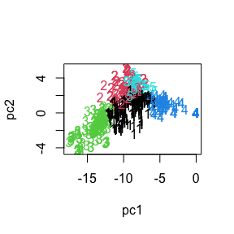

```r
##Perform eigenvalue decomposition for clustering
##And select cluster 5 as target set to predict
pcNum=25
svdWheat <- svd(D, nu = pcNum, nv = pcNum)
PCWheat <- D %*% svdWheat$v
rownames(PCWheat) <- rownames(D)
DistWheat <- dist(PCWheat)
TreeWheat <- cutree(hclust(DistWheat), k = 5 )
plot(PCWheat[,1], PCWheat[,2], col = TreeWheat,
     pch = as.character(TreeWheat), xlab = "pc1", ylab = "pc2")
```

```r
vp <- rownames(PCWheat)[TreeWheat == 3]; length(vp)
```

```
## [1] 159
```

```r
tp <- setdiff(rownames(PCWheat),vp)
```

#### 3a) Optimizing a subsample of size N to be representative of its own

Since the objective is to select a set of 100 lines that represent best the training set (tp) of ~400 lines we will subset a relationship matrix for that training set (As).

```r
As <- D[tp,tp]
DT2 <- DT[rownames(As),]
```

For this particular case there is no trait to optimize (x’a) but we just want to make sure that we maintain as much variation in the sample as possible (x’Ax). We then just create a dummy trait in the dataset (dummy) to put all the weight into the group relationship (x’Ax) using the lambda argument. The trait for occurrence we will use it as before to control the number of individuals to be in the sample.

```r
# res<-evolafit(cbind(dummy, occ)~id, dt= DT2,
#                 # constraints: if sum is greater than this ignore
#                 constraintsUB = c(Inf, 100),
#                 # constraints: if sum is smaller than this ignore
#                 constraintsLB= c(-Inf, -Inf),
#                 # weight the traits for the selection
#                 b = c(1,0),
#                 # population parameters
#                 nCrosses = 100, nProgeny = 10,
#                 # coancestry parameters
#                 D=As,
#                 lambda=(60*pi)/180, nQtlStart = 80,
#                 # selection parameters
#                 propSelBetween = 0.5, propSelWithin =0.5,
#                 nGenerations = 15, verbose = FALSE)
#
# Q <- pullQtlGeno(res$pop, simParam = res$simParam, trait=1); Q <- Q/2
# best = bestSol(res$pop)[,1]
# sum(Q[best,]) # total # of inds selected
```

You can see which individuals were selected.

```r
# cex <- rep(0.5,nrow(PCWheat))
# names(cex) <- rownames(PCWheat)
# cex[names(which(Q[best,]==1))]=2
# plot(PCWheat[,1], PCWheat[,2], col = TreeWheat, cex=cex,
#      pch = TreeWheat, xlab = "pc1", ylab = "pc2")
```

### 3b) Optimizing a subsample of size N to be representative of another population

we can use the covariance between the training population and the validation population to create a new trait (x’a) that can be used in addition to the group relationship (x’Ax).

```r
DT2$cov <- apply(D[tp,vp],1,mean)
```

The model can be specified as before with the suttle difference that the covariance between the training and validation population contributes to the fitness function.

```r
# res<-evolafit(cbind(cov, occ)~id, dt= DT2,
#                 # constraints: if sum is greater than this ignore
#                 constraintsUB = c(Inf, 100),
#                 # constraints: if sum is smaller than this ignore
#                 constraintsLB= c(-Inf, -Inf),
#                 # weight the traits for the selection
#                 b = c(1,0),
#                 # population parameters
#                 nCrosses = 100, nProgeny = 10,
#                 # coancestry parameters
#                 D=As,
#                 lambda=(60*pi)/180, nQtlStart = 80,
#                 # selection parameters
#                 propSelBetween = 0.5, propSelWithin =0.5,
#                 nGenerations = 15, verbose = FALSE)
#
# Q <- pullQtlGeno(res$pop, simParam = res$simParam, trait=1); Q <- Q/2
# best = bestSol(res$pop)[,1]
# sum(Q[best,]) # total # of inds selected
```

You can plot the final results and see which individuals were picked.

```r
# cex <- rep(0.5,nrow(PCWheat))
# names(cex) <- rownames(PCWheat)
# cex[names(which(Q[best,]==1))]=2
# plot(PCWheat[,1], PCWheat[,2], col = TreeWheat, cex=cex,
#      pch = TreeWheat, xlab = "pc1", ylab = "pc2")
```

#### Gender in breeding

In this case is better if you only create the cross combinations that are possible (e.g., where male and female can couple) and you handed them to the evolutionary algorithm. That means, the rows of the crosses to be in the searching space only include the realistic ones.

#### Number of times a parent should be used

In this case you can modify the fitness function to set to a low value the fitness of solutions that have used too many times the same parent. Using the DT_technow dataset this would be done the following way:

First you create an incidence matrix for parents in columns and hybrids in crosses:

```r
data(DT_technow, package="enhancer")
DT <- DT_technow
DT$occ <- 1; DT$occ[1]=0

Md <- apply(Md_technow,2,as.numeric)
rownames(Md) <- rownames(Md_technow)
Mf <- apply(Mf_technow,2,as.numeric)
rownames(Mf) <- rownames(Mf_technow)
M <- rbind(Md,Mf)

D <- A.matr(M)

Z=with(DT,overlay(dent,flint) )#  Matrix::sparse.model.matrix(~dent-1, data=DT)
rownames(Z) <- DT$hy # needed to link to the QTL matrix
```

```r
# regular fitness function
fitnessf <-function (Y, b, d, Q, Z) {
  fit <- Y %*% b - d
  return(fit)
}
# new fitness function with constraint
fitnessf <-function (Y, b, Q, D, a, lambda, scale=TRUE, Z) {
  X=Q%*%Z[colnames(Q),]
  bad <- as.vector( apply(X,1, function(x){length(which(x > 5))}) )
  bad <- which(bad > 0)
  # (q'a)b - l(q'Dq)
  if(scale){
    fit <- stan( apply(Y,2,scale) %*% b) -  lambda*stan( Matrix::diag(Q %*% Matrix::tcrossprod(D, Q)) )
  }else{
    fit <- stan( Y %*% b) -  lambda*stan( Matrix::diag(Q %*% Matrix::tcrossprod(D, Q)) )
  }
  if(length(bad) > 0){fit[bad,1]=min(fit[,1])}
  return(fit)
}
```

Notice that we have added a matrix product Q%*%Z to see how may times each parent is used in the proposed solution of crosses. The next step would be to provide the new fitness function to the evolafit() function and the additional argument Z which is the overlay matrix formed in the first chunck of code:

```r
# silent for CRAN checks restriction on time
# res<-evolafit(formula = c(GY, occ)~hy,
#               dt= DT,
#               # constraints: if sum is greater than this ignore
#               constraintsUB = c(Inf,50),
#               # constraints: if sum is smaller than this ignore
#               constraintsLB= c(-Inf,-Inf),
#               # weight the traits for the selection
#               b = c(1,0),
#               # population parameters
#               nCrosses = 100, nProgeny = 10,
#               # coancestry parameters
#               D=D, lambda= (10*pi)/180 , nQtlStart = 40,
#               # new fitness function and additional args
#               fitnessf = fitnessf, Z=Z,
#               # selection parameters
#               propSelBetween = 0.5, propSelWithin =0.5,
#               nGenerations = 15, verbose=FALSE)
#
# Q <- pullQtlGeno(res$pop, simParam = res$simParam, trait=1); Q <- Q/2
# best = bestSol(res$pop)[,1]
# qa = (Q %*% DT$GY)[best,]; qa
# qDq = Q[best,] %*% D %*% Q[best,]; qDq
# sum(Q[best,]) # total # of inds selected
```

Now, last but not least we check how many times each parent was used:

```r
# # check how many times an individual was used in the final crosses
# crosses <- data.frame(cross=names(which( Q[best,] == 1)))
# table(unlist(strsplit(crosses$cross,":")))
# # check performance of crosses selected
# plot(DT$GY, col=as.factor(Q[best,]),
#        pch=(Q[best,]*19)+1)
```

### 6) Customizing a fitness function (linear regression example)

The following example show how the genetic algorithm can be tweeked to do a predictive model of the type of of a linear regression.

```r
# data("mtcars")
# # we scale the variables
# mtcars <- as.data.frame(apply(mtcars,2,scale))
# mtcars$inter <- 1 # add an intercept if desired
#
# # define the train and validation set
# train <- sample(1:nrow(mtcars) , round((nrow(mtcars)*.4)))
# validate <- setdiff(1:nrow(mtcars),train)
# mtcarsT <- mtcars[train,]
# mtcarsV <- mtcars[validate,]
#
# ##############################
# # fit the regular linear model
# head(mtcarsT)
# mod <- lm(mpg~cyl+disp+hp+drat, data=mtcarsT);mod
#
# ##############################
# # fit the genetic algorithm
# # 1) create initial QTL effects to evolve
# nqtls=100
# dt <- data.frame(alpha=rnorm(nqtls,0,.3),qtl=paste0("Q",1:nqtls))
# head(dt); nrow(dt)
#
# # generate n samples equivalent to the number of progeny
# # you are planning to start the simulation with (e.g., 500)
# # these are fixed values
# sam <- sample(1:nrow(mtcarsT),500,replace = TRUE)
# y <- mtcarsT$mpg[sam]
# X = mtcarsT[sam,c("cyl","disp","hp","drat")]
#
# # Task: linear regression
# res0<-evolafit(alpha~qtl, dt= dt,
#                # constraints: if greater than this ignore
#                constraintsUB = c(Inf),
#                # constraints: if smaller than this ignore
#                constraintsLB= c(-Inf),
#                # weight the traits for the selection
#                b = c(1),
#                # population parameters
#                nCrosses = 50, nProgeny = 10, recombGens = 1,
#                # coancestry parameters
#                D=NULL, lambda=0, nQtlStart = 4, fixNumQtlPerInd = TRUE,
#                # least MSE function (y - Xb)^2; Y are betas; X*Y is X*beta;
#                # Y and X are fixed, we just evolve the betas
#                fitnessf=regFun,
#                # selection parameters
#                propSelBetween = 0.65, propSelWithin =0.65, selectTop=FALSE,
#                nGenerations = 10, y=y, X=X, verbose = FALSE
# )
#
# # check how the fitness function changed across generations
# evolmonitor(res0, kind = 1)
# # this time the best solution is the one that minimizes the error
# Q <- pullQtlGeno(res0$pop, simParam = res0$simParam, trait=1); Q <- Q/2
# bestid <- bestSol(res0$pop, selectTop = FALSE)[,"fitness"]
# bestid
# betas <- res0$simParam$traits[[1]]@addEff[which(Q[bestid,] > 0)]
# betas
#
# # plot predicted versus real values
# plot( as.matrix(mtcarsV[,c("cyl","disp","hp","drat")]) %*% betas  , mtcarsV$mpg,
#       xlab="predicted mpg value by GA", ylab="mpg",
#       main="Correlation between GA-prediction and observed") # GA
# plot( as.matrix(mtcarsV[,c("inter","cyl","disp","hp","drat")]) %*% mod$coefficients , mtcarsV$mpg,
#       xlab="predicted mpg value by lm", ylab="mpg",
#       main="Correlation between lm-prediction and observed") # LM
# # Correlation between GA-prediction and observed
# cor( as.matrix(mtcarsV[,c("cyl","disp","hp","drat")]) %*% betas  , mtcarsV$mpg)
# # Correlation between lm-prediction and observed
# cor( as.matrix(mtcarsV[,c("inter","cyl","disp","hp","drat")]) %*% mod$coefficients , mtcarsV$mpg) # LM
#
```

### 7) Travel salesman problem

A popular problem to optimize is the one of a travel salesman person that needs to go to n cities while minimizing the distance incurred. The way to specify the problem in evola is the following:

Let us start by defining some functions to simulate and plot n cities with their coordinates.

```r
# "not in" operator
'%!in%' <- function(x,y)!('%in%'(x,y))

# function to simulate cities
simCities <- function(n_cities = 5) {
  # extend "LETTERS" function to run from "A" to "ZZ"
  MORELETTERS <- c(LETTERS, sapply(LETTERS, function(x) paste0(x, LETTERS)))
  cities <- matrix(runif(2*n_cities,-1,1),ncol=2)
  rownames(cities) <- MORELETTERS[1:n_cities]
  colnames(cities) <- c("x","y")
  return(cities)
}

# function to plot cities
plotCities <- function(cities, route, dist=NULL,
                      main="", bg="white",
                      main_col = "black",
                      point_col = "deepskyblue",
                      start_col = "red",
                      line_col = "black") {
  # plot cities
  city_colors <- c(start_col, rep(point_col,nrow(cities)))

  par(bg=bg)
  plot(cities,
       pch=16, cex=3,
       col=point_col,
       ylim=c(-1,1.1), xlim=c(-1,1),
       # yaxt="n", xaxt="n",
       # ylab="", xlab="",
       bty="n",
       main=main, col.main=main_col)
  text(x=cities[,1], y=cities[,2], labels=rownames(cities))
  # plot route
  if(!missing(route)){
    for(i in 1:length(route)) {
      if(route[i]>0){
        nodes0 <- strsplit(names(route)[i], "-")[[1]]
        lines(x=cities[nodes0,"x"],
              y=cities[nodes0,"y"],
              col=line_col,
              lwd=1.5)
      }
    }
  }
  # add distance in legend
  if(!is.null(dist)) legend("topleft",
                            bty="n", # no box around legend
                            legend=round(dist,4),
                            bg="transparent",
                            text.col="black")

}

# function to compute adjacency matrix
compAdjMat <- function(cities) return(as.matrix(dist(cities)))
```

with such functions defined let us start simulating the problem:

```r
nCities=5
cities <- simCities(nCities)
adjmat <- compAdjMat(cities)
# make the distance matrix a data frame
df2 <- as.data.frame(as.table(adjmat))
df2 <- df2[-which(df2$Var1 == df2$Var2),]
colnames(df2)[3] <- c("distances")
df2$route <- paste(df2$Var1, df2$Var2, sep="-")
df2
```

```
##    Var1 Var2 distances route
## 2     B    A 1.1522360   B-A
## 3     C    A 0.6729371   C-A
## 4     D    A 0.4026782   D-A
## 5     E    A 0.7418513   E-A
## 6     A    B 1.1522360   A-B
## 8     C    B 1.6628691   C-B
## 9     D    B 1.2374269   D-B
## 10    E    B 1.3306519   E-B
## 11    A    C 0.6729371   A-C
## 12    B    C 1.6628691   B-C
## 14    D    C 0.4258592   D-C
## 15    E    C 0.5226517   E-C
## 16    A    D 0.4026782   A-D
## 17    B    D 1.2374269   B-D
## 18    C    D 0.4258592   C-D
## 20    E    D 0.3442195   E-D
## 21    A    E 0.7418513   A-E
## 22    B    E 1.3306519   B-E
## 23    C    E 0.5226517   C-E
## 24    D    E 0.3442195   D-E
```

Since the QTLs will be the different routes and the average allelic effects the distances we need to keep track of the cities (nodes) implied in the different routes (edges), we will create an incidence matrix of cities implied in each possible route step.

```r
H <- with(df2, overlay(Var1,Var2) )
rownames(H) <- df2$route
head(H)
```

```
##     A B C D E
## B-A 1 1 0 0 0
## C-A 1 0 1 0 0
## D-A 1 0 0 1 0
## E-A 1 0 0 0 1
## A-B 1 1 0 0 0
## C-B 0 1 1 0 0
```

Now we need to define what will be our objective function to score the different possible solutions or combinations of possible routes to take. If you are familiar with evola you know that certain internal variable names are taken such as Y, b, d, Q, D and a which represent different sources of information. We recommend you to read the evolafit documentation. We will use the regular fitness function that gives value to solutions based on the crossproduct of QTLs by average allelic effects but we will add some constraints. These are to ensure that all cities are visited and that all cities are left so there’s no open edges.

```r
salesf <- function(Y,b,Q,D,a,lambda ,H, nCities){
                # simple fitness function
                fitnessVal <-  (Y%*%b)
                ###############
                # CONSTRAINTS
                ###############
                # calculate how many cities the solution has travelled to
                QH <- Q %*% H
                # ensure all cities have at least 2 edges
                edgeCheck <- apply(QH,1,function(x){if(all(x>1)){return(1)}else{return(0)} })
                #apply condition on arriving and leaving the city
                fitnessVal <- ifelse(edgeCheck == 0, Inf, fitnessVal) # if not touching at least 2 cities give inf distance
                # number of unique cities visited
                nCityCheck <- apply(QH,1,function(x){length(which(x > 0))})
                # apply condition on visiting all cities
                fitnessVal <- ifelse(nCityCheck < nCities, Inf, fitnessVal) # if not in all cities give an infinite distance
                return(fitnessVal)
              }
```

With the fitness function defined now we can fit the genetic algorithm:

```r
# res<-evolafit(formula=distances~route, dt= df2,
#               # constraints on traits: if greater than this ignore
#               constraintsUB = c(Inf),
#               # constraints on traits: if smaller than this ignore
#               constraintsLB= c(-Inf),
#               # weight the traits for the selection (fitness function)
#               b = c(1),
#               # population parameters
#               nCrosses = 50, nProgeny = 10,
#               # genome parameters
#               recombGens = 1, nChr=1, mutRateAllele=0,
#               # start with at least n QTLs equivalent to n cities
#               nQtlStart = nCities*2,
#               # coancestry parameters
#               D=NULL, lambda=0,
#               fitnessf = salesf,
#               selectTop = FALSE,
#               # additional variables for the fitness function
#               H=H, nCities=nCities,
#               # selection parameters
#               # propSelBetween = .8, propSelWithin =0.8,
#               nGenerations = 50, verbose=FALSE
# )
#
# evolmonitor(res, kind=1) # fitness should decrease
# Q <- pullQtlGeno(res$pop, simParam = res$simParam, trait=1); Q <- Q/2
# best <- bestSol(res$pop, selectTop = FALSE)[,"fitness"]
# Q[best,] # routes taken
# Q[best,] %*% H # cities visited (should have a 2 so we arrived and left once)
#
# plotCities(cities, route=Q[best,])
```

### 8) How to force the initial solutions or founders

Using the Gems example we will show how to create the initial haplotypes for the founder solutions. This can be particularly useful if you want to provide initial good solutions (for example, when the constraints are too strict) to make the search easier.

```r
set.seed(1)
# Data
Gems <- data.frame(
  Color = c("Red", "Blue", "Purple", "Orange",
            "Green", "Pink", "White", "Black",
            "Yellow"),
  Weight = round(runif(9,0.5,5),2),
  Value = round(abs(rnorm(9,0,5))+0.5,2),
  Times=c(rep(1,8),0)
)

# create initial haplotypes where all are the same solution so the breeding program won't evolve
# only when variability exist evolution can happen
av <- 1:nrow(Gems)
Ne=5
haplo = matrix(as.raw(0), nrow= Ne*2, ncol = nrow(Gems)) # rbind( diag(nrow(dt)), diag(nrow(dt)) )
for (i in seq(1,nrow(haplo),2)) {
  haplo[i,c(1,3)] <- as.raw(1)
  haplo[(i+1),] <- haplo[i,]
}
haplo
```

```
##       [,1] [,2] [,3] [,4] [,5] [,6] [,7] [,8] [,9]
##  [1,]   01   00   01   00   00   00   00   00   00
##  [2,]   01   00   01   00   00   00   00   00   00
##  [3,]   01   00   01   00   00   00   00   00   00
##  [4,]   01   00   01   00   00   00   00   00   00
##  [5,]   01   00   01   00   00   00   00   00   00
##  [6,]   01   00   01   00   00   00   00   00   00
##  [7,]   01   00   01   00   00   00   00   00   00
##  [8,]   01   00   01   00   00   00   00   00   00
##  [9,]   01   00   01   00   00   00   00   00   00
## [10,]   01   00   01   00   00   00   00   00   00
```

```r
# simple specification
# res00<-evolafit(formula=cbind(Weight,Value)~Color, dt= Gems,
#                 # constraints on traits: if greater than this ignore
#                 constraintsUB = c(10,Inf), nGenerations = 10,
#                 haplo=haplo
# )
# best = bestSol(res00$pop)[,"fitness"]
# Q <- pullQtlGeno(res00$pop, simParam = res00$simParam, trait=1); Q <- Q/2
# qa = Q[best,] %*% as.matrix(Gems[,c("Weight","Value")]); qa
# Q[best,] # only possible solution
```

The advice here is to upload directly the phased genotypes (haplotypes) to the AlphaSimR machinery and simulate the possible crosses to explore how many individuals are required to sample a given trait (oligogenic or polygenic) with a given probablility. You can also use the inbreeding value of each cross to decide the number of progeny for a given cross since there is a negative relationship between inbreeding of a cross and the expected variance observed in the progeny of such cross. No need to use the evola package.

## Literature

Giovanny Covarrubias-Pazaran (2024). evola: a simple evolutionary algorithm for optimization of complex problems. To be submitted to Bioinformatics.

Gaynor, R. Chris, Gregor Gorjanc, and John M. Hickey. 2021. AlphaSimR: an R package for breeding program simulations. G3 Gene|Genomes|Genetics 11(2):jkaa017. https://doi.org/10.1093/g3journal/jkaa017.

Chen GK, Marjoram P, Wall JD (2009). Fast and Flexible Simulation of DNA Sequence Data. Genome Research, 19, 136-142.